# Reviewers comment v1

Hello Kylee!

I'm happy to review your project today 🙌

My name is **Gerardo Flores** and you can find me on the HUB as https://hub.tripleten.com/u/dea170e1

You can find my comments under the heading **«Review»**. I will categorize my comments in green, blue or red boxes like this:

**Success:** if everything is done successfully

**Remarks:** if I can give some recommendations or ways to improve the project

**Needs fixing:** if the block requires some corrections. Work cant be accepted with the red comments

Please don't remove my comments :) If you have any questions don't hesitate to respond to my comments in a different section.

**Student comments:** For example like this

**Reviewer's comment v1:**

**Overall Feedback**

Hello Kylee,

You’ve submitted another project—great work! Your commitment to pushing through the challenges of this program is admirable.

After reviewing your submission, I’ve returned it with some feedback to help you make the necessary improvements.

You can find my more detailed notes within your project notebook in the `Reviewer's comment v1:` section.

**🚧 Suggested Tweaks & Areas for Attention**

- Perform your hypothesis tests.
- Update your final conlusions

Keep in mind that revisions are a normal and valuable part of the learning process. Use this feedback to refine your work and resubmit when you’re ready. I know you’re capable of great things, and I’m here to support you every step of the way. Keep going—you’re doing a great job! 🏄

If you find yourself uncertain or in need of further insights, never hesitate to consult with your tutor or ask your questions here. We are here to guide and assist you.

**Reviewer's comment v2:**

**Overall Feedback**

Hello Kylee,

You’ve resubmitted another project—great work! Your commitment to pushing through the challenges of this program is admirable.

After reviewing your submission, it is now approved.

You can find my more detailed notes within your project notebook in the `Reviewer's comment v2:` section.

If you find yourself uncertain or in need of further insights, never hesitate to consult with your tutor or ask your questions here. We are here to guide and assist you.

# Which one is a better plan?

You work as an analyst for the telecom operator Megaline. The company offers its clients two prepaid plans, Surf and Ultimate. The commercial department wants to know which of the plans brings in more revenue in order to adjust the advertising budget.

You are going to carry out a preliminary analysis of the plans based on a relatively small client selection. You'll have the data on 500 Megaline clients: who the clients are, where they're from, which plan they use, and the number of calls they made and text messages they sent in 2018. Your job is to analyze the clients' behavior and determine which prepaid plan brings in more revenue.

**Reviewer's comment v1**

Great job keeping the additional information about the project goal! Additionally, you could add a short description of the tasks you plan to perform and the available data. This information could be helpful for the notebook reader.

[We've provided you with some commentary to guide your thinking as you complete this project. However, make sure to remove all the bracketed comments before submitting your project.]

[Before you dive into analyzing your data, explain for yourself the purpose of the project and actions you plan to take.]

[Please bear in mind that studying, amending, and analyzing data is an iterative process. It is normal to return to previous steps and correct/expand them to allow for further steps.]

## Initialization

```python
import pandas as pd
import numpy as np
import matplotlib.pyplot as plt
import seaborn as sns
from scipy import stats as st
import math
```

## Load data

```python
users = pd.read_csv('/datasets/megaline_users.csv')
calls = pd.read_csv('/datasets/megaline_calls.csv')
messages = pd.read_csv('/datasets/megaline_messages.csv')
internet = pd.read_csv('/datasets/megaline_internet.csv')
plans = pd.read_csv('/datasets/megaline_plans.csv')
```

## Prepare the data

[The data for this project is split into several tables. Explore each one to get an initial understanding of the data. Do necessary corrections to each table if necessary.]

## Plans

```python
plans.head()
```

|  | messages_included | mb_per_month_included | minutes_included | usd_monthly_pay | usd_per_gb | usd_per_message | usd_per_minute | plan_name |
| --- | --- | --- | --- | --- | --- | --- | --- | --- |
| 0 | 50 | 15360 | 500 | 20 | 10 | 0.03 | 0.03 | surf |
| 1 | 1000 | 30720 | 3000 | 70 | 7 | 0.01 | 0.01 | ultimate |

```python
plans.info()
```

```
<class 'pandas.core.frame.DataFrame'>
RangeIndex: 2 entries, 0 to 1
Data columns (total 8 columns):
 #   Column                 Non-Null Count  Dtype
---  ------                 --------------  -----
 0   messages_included      2 non-null      int64
 1   mb_per_month_included  2 non-null      int64
 2   minutes_included       2 non-null      int64
 3   usd_monthly_pay        2 non-null      int64
 4   usd_per_gb             2 non-null      int64
 5   usd_per_message        2 non-null      float64
 6   usd_per_minute         2 non-null      float64
 7   plan_name              2 non-null      object
dtypes: float64(2), int64(5), object(1)
memory usage: 256.0+ bytes
```

```python
plans.describe()
```

|  | messages_included | mb_per_month_included | minutes_included | usd_monthly_pay | usd_per_gb | usd_per_message | usd_per_minute |
| --- | --- | --- | --- | --- | --- | --- | --- |
| count | 2.000000 | 2.000000 | 2.000000 | 2.000000 | 2.00000 | 2.000000 | 2.000000 |
| mean | 525.000000 | 23040.000000 | 1750.000000 | 45.000000 | 8.50000 | 0.020000 | 0.020000 |
| std | 671.751442 | 10861.160159 | 1767.766953 | 35.355339 | 2.12132 | 0.014142 | 0.014142 |
| min | 50.000000 | 15360.000000 | 500.000000 | 20.000000 | 7.00000 | 0.010000 | 0.010000 |
| 25% | 287.500000 | 19200.000000 | 1125.000000 | 32.500000 | 7.75000 | 0.015000 | 0.015000 |
| 50% | 525.000000 | 23040.000000 | 1750.000000 | 45.000000 | 8.50000 | 0.020000 | 0.020000 |
| 75% | 762.500000 | 26880.000000 | 2375.000000 | 57.500000 | 9.25000 | 0.025000 | 0.025000 |
| max | 1000.000000 | 30720.000000 | 3000.000000 | 70.000000 | 10.00000 | 0.030000 | 0.030000 |

```python
plans.shape
```

```
(2, 8)
```

This data seems pretty clean. It is visually appleasing by not having an overload, I can easily see the differences.

## Fix data

```python
plans=plans.rename(columns=
                   {'usd_monthly_pay':'monthly_cost'})
```

## Enrich data

Let's simplify things.

```python
plans['gb_per_month_included']=plans['mb_per_month_included']/1024
```

```python
plans=plans.reset_index()
plans['plan_name']=plans['plan_name'].str.lower().str.strip()
```

```python
plans['included_value_usd_amount']=(plans['minutes_included']*plans['usd_per_minute']+plans['messages_included']*plans['usd_per_message']+plans['gb_per_month_included']*plans['usd_per_gb'])
```

```python
plans
```

|  | index | messages_included | mb_per_month_included | minutes_included | monthly_cost | usd_per_gb | usd_per_message | usd_per_minute | plan_name | gb_per_month_included | included_value_usd_amount |
| --- | --- | --- | --- | --- | --- | --- | --- | --- | --- | --- | --- |
| 0 | 0 | 50 | 15360 | 500 | 20 | 10 | 0.03 | 0.03 | surf | 15.0 | 166.5 |
| 1 | 1 | 1000 | 30720 | 3000 | 70 | 7 | 0.01 | 0.01 | ultimate | 30.0 | 250.0 |

## Users

```python
users.head()# Print the general/summary information about the users' DataFrame
```

|  | user_id | first_name | last_name | age | city | reg_date | plan | churn_date |
| --- | --- | --- | --- | --- | --- | --- | --- | --- |
| 0 | 1000 | Anamaria | Bauer | 45 | Atlanta-Sandy Springs-Roswell, GA MSA | 2018-12-24 | ultimate | NaN |
| 1 | 1001 | Mickey | Wilkerson | 28 | Seattle-Tacoma-Bellevue, WA MSA | 2018-08-13 | surf | NaN |
| 2 | 1002 | Carlee | Hoffman | 36 | Las Vegas-Henderson-Paradise, NV MSA | 2018-10-21 | surf | NaN |
| 3 | 1003 | Reynaldo | Jenkins | 52 | Tulsa, OK MSA | 2018-01-28 | surf | NaN |
| 4 | 1004 | Leonila | Thompson | 40 | Seattle-Tacoma-Bellevue, WA MSA | 2018-05-23 | surf | NaN |

```python
users.info()
```

```
<class 'pandas.core.frame.DataFrame'>
RangeIndex: 500 entries, 0 to 499
Data columns (total 8 columns):
 #   Column      Non-Null Count  Dtype
---  ------      --------------  -----
 0   user_id     500 non-null    int64
 1   first_name  500 non-null    object
 2   last_name   500 non-null    object
 3   age         500 non-null    int64
 4   city        500 non-null    object
 5   reg_date    500 non-null    object
 6   plan        500 non-null    object
 7   churn_date  34 non-null     object
dtypes: int64(2), object(6)
memory usage: 31.4+ KB
```

```python
users.describe()
```

|  | user_id | age |
| --- | --- | --- |
| count | 500.000000 | 500.000000 |
| mean | 1249.500000 | 45.486000 |
| std | 144.481833 | 16.972269 |
| min | 1000.000000 | 18.000000 |
| 25% | 1124.750000 | 30.000000 |
| 50% | 1249.500000 | 46.000000 |
| 75% | 1374.250000 | 61.000000 |
| max | 1499.000000 | 75.000000 |

```python
users.shape
```

```
(500, 8)
```

```python
print(users.sample(10))
```

```
     user_id first_name  last_name  age  \
492     1492      Elvie      Jones   63
332     1332      Lucas   Saunders   37
259     1259     Etsuko      Perry   63
37      1037      Reena  Velazquez   20
370     1370     Nenita    Vasquez   49
112     1112       Amal    Pacheco   18
427     1427      Zofia      Brock   64
318     1318       Huey      Walsh   54
322     1322      Tyler    Sweeney   22
400     1400     Kenton    Hickman   72

                                                 city    reg_date      plan  \
492           Portland-Vancouver-Hillsboro, OR-WA MSA  2018-03-07      surf
332             Atlanta-Sandy Springs-Roswell, GA MSA  2018-03-12      surf
```

[output cut: 20 more lines]

I notice that the column 'city' appears to be more so a "market" because most of the values in the column contain multiple cities in that same area, some sharing multiple states. In the 'churn_date' column, majority of the values are called "NaN", meaning that the service was still active at the time the report was drawn. Date format is Y/M/D.

### Fix Data

[Fix obvious issues with the data given the initial observations.]

```python
users=users.rename(columns={'reg_date':'member_since','city':'major_metro_region','churn_date':'cancelled_date'})
```

```python
users
```

|  | user_id | first_name | last_name | age | major_metro_region | member_since | plan | cancelled_date |
| --- | --- | --- | --- | --- | --- | --- | --- | --- |
| 0 | 1000 | Anamaria | Bauer | 45 | Atlanta-Sandy Springs-Roswell, GA MSA | 2018-12-24 | ultimate | NaN |
| 1 | 1001 | Mickey | Wilkerson | 28 | Seattle-Tacoma-Bellevue, WA MSA | 2018-08-13 | surf | NaN |
| 2 | 1002 | Carlee | Hoffman | 36 | Las Vegas-Henderson-Paradise, NV MSA | 2018-10-21 | surf | NaN |
| 3 | 1003 | Reynaldo | Jenkins | 52 | Tulsa, OK MSA | 2018-01-28 | surf | NaN |
| 4 | 1004 | Leonila | Thompson | 40 | Seattle-Tacoma-Bellevue, WA MSA | 2018-05-23 | surf | NaN |
| ... | ... | ... | ... | ... | ... | ... | ... | ... |
| 495 | 1495 | Fidel | Sharpe | 67 | New York-Newark-Jersey City, NY-NJ-PA MSA | 2018-09-04 | surf | NaN |
| 496 | 1496 | Ariel | Shepherd | 49 | New Orleans-Metairie, LA MSA | 2018-02-20 | surf | NaN |
| 497 | 1497 | Donte | Barrera | 49 | Los Angeles-Long Beach-Anaheim, CA MSA | 2018-12-10 | ultimate | NaN |
| 498 | 1498 | Scot | Williamson | 51 | New York-Newark-Jersey City, NY-NJ-PA MSA | 2018-02-04 | surf | NaN |
| 499 | 1499 | Shena | Dickson | 37 | Orlando-Kissimmee-Sanford, FL MSA | 2018-05-06 | surf | NaN |

500 rows × 8 columns

### Enrich Data

[Add additional factors to the data if you believe they might be useful.]

```python
users['member_since']=pd.to_datetime(users['member_since'])
users['cancelled_date']=pd.to_datetime(users['cancelled_date'],errors='coerce')
```

```python
users.head()
```

|  | user_id | first_name | last_name | age | major_metro_region | member_since | plan | cancelled_date |
| --- | --- | --- | --- | --- | --- | --- | --- | --- |
| 0 | 1000 | Anamaria | Bauer | 45 | Atlanta-Sandy Springs-Roswell, GA MSA | 2018-12-24 | ultimate | NaT |
| 1 | 1001 | Mickey | Wilkerson | 28 | Seattle-Tacoma-Bellevue, WA MSA | 2018-08-13 | surf | NaT |
| 2 | 1002 | Carlee | Hoffman | 36 | Las Vegas-Henderson-Paradise, NV MSA | 2018-10-21 | surf | NaT |
| 3 | 1003 | Reynaldo | Jenkins | 52 | Tulsa, OK MSA | 2018-01-28 | surf | NaT |
| 4 | 1004 | Leonila | Thompson | 40 | Seattle-Tacoma-Bellevue, WA MSA | 2018-05-23 | surf | NaT |

## Calls

```python
calls.info()# Print the general/summary information about the calls' DataFrame
```

```
<class 'pandas.core.frame.DataFrame'>
RangeIndex: 137735 entries, 0 to 137734
Data columns (total 4 columns):
 #   Column     Non-Null Count   Dtype
---  ------     --------------   -----
 0   id         137735 non-null  object
 1   user_id    137735 non-null  int64
 2   call_date  137735 non-null  object
 3   duration   137735 non-null  float64
dtypes: float64(1), int64(1), object(2)
memory usage: 4.2+ MB
```

```python
calls.shape
```

```
(137735, 4)
```

```python
calls.describe()
```

|  | user_id | duration |
| --- | --- | --- |
| count | 137735.000000 | 137735.000000 |
| mean | 1247.658046 | 6.745927 |
| std | 139.416268 | 5.839241 |
| min | 1000.000000 | 0.000000 |
| 25% | 1128.000000 | 1.290000 |
| 50% | 1247.000000 | 5.980000 |
| 75% | 1365.000000 | 10.690000 |
| max | 1499.000000 | 37.600000 |

```python
calls
```

|  | id | user_id | call_date | duration |
| --- | --- | --- | --- | --- |
| 0 | 1000_93 | 1000 | 2018-12-27 | 8.52 |
| 1 | 1000_145 | 1000 | 2018-12-27 | 13.66 |
| 2 | 1000_247 | 1000 | 2018-12-27 | 14.48 |
| 3 | 1000_309 | 1000 | 2018-12-28 | 5.76 |
| 4 | 1000_380 | 1000 | 2018-12-30 | 4.22 |
| ... | ... | ... | ... | ... |
| 137730 | 1499_199 | 1499 | 2018-11-21 | 8.72 |
| 137731 | 1499_200 | 1499 | 2018-10-20 | 10.89 |
| 137732 | 1499_201 | 1499 | 2018-09-21 | 8.12 |
| 137733 | 1499_202 | 1499 | 2018-10-10 | 0.37 |
| 137734 | 1499_203 | 1499 | 2018-12-29 | 13.86 |

137735 rows × 4 columns

```python
print(calls.sample(10))# Print a sample of data for calls
```

```
              id  user_id   call_date  duration
137098   1498_19     1498  2018-04-03     11.80
9344    1042_273     1042  2018-05-29      4.12
71700   1255_371     1255  2018-10-25      9.12
30986   1116_138     1116  2018-08-22      0.77
60320   1217_141     1217  2018-10-10      4.08
83296    1302_70     1302  2018-11-05     16.83
137584   1499_53     1499  2018-09-05     16.62
67652    1243_40     1243  2018-11-04      4.30
128305  1460_424     1460  2018-08-01     10.15
129413  1465_842     1465  2018-09-20      3.73
```

[Describe what you see and notice in the general information and the printed data sample for the above price of data. Are there any issues (inappropriate data types, missing data etc) that may need further investigation and changes? How that can be fixed?]

### Fix data

[Fix obvious issues with the data given the initial observations.]

```python
calls=calls.rename(columns={'id':'caller_id_per_user'})
calls['duration_rounded']=calls['duration'].apply(math.ceil)
calls['call_date']=pd.to_datetime(calls['call_date'])
```

```python
calls
```

|  | caller_id_per_user | user_id | call_date | duration | duration_rounded |
| --- | --- | --- | --- | --- | --- |
| 0 | 1000_93 | 1000 | 2018-12-27 | 8.52 | 9 |
| 1 | 1000_145 | 1000 | 2018-12-27 | 13.66 | 14 |
| 2 | 1000_247 | 1000 | 2018-12-27 | 14.48 | 15 |
| 3 | 1000_309 | 1000 | 2018-12-28 | 5.76 | 6 |
| 4 | 1000_380 | 1000 | 2018-12-30 | 4.22 | 5 |
| ... | ... | ... | ... | ... | ... |
| 137730 | 1499_199 | 1499 | 2018-11-21 | 8.72 | 9 |
| 137731 | 1499_200 | 1499 | 2018-10-20 | 10.89 | 11 |
| 137732 | 1499_201 | 1499 | 2018-09-21 | 8.12 | 9 |
| 137733 | 1499_202 | 1499 | 2018-10-10 | 0.37 | 1 |
| 137734 | 1499_203 | 1499 | 2018-12-29 | 13.86 | 14 |

137735 rows × 5 columns

### Enrich data

[Add additional factors to the data if you believe they might be useful.]

```python
calls['year_month'] = calls['call_date'].dt.to_period('M')

user_stats=calls.groupby('user_id').agg({
    'duration':'sum',
    'duration_rounded':'sum',
    'user_id':'count'
})
```

```python
user_stats
```

| user_id | duration | duration_rounded | user_id |
| --- | --- | --- | --- |
| 1000 | 116.83 | 124 | 16 |
| 1001 | 1640.46 | 1728 | 261 |
| 1002 | 777.13 | 829 | 113 |
| 1003 | 1041.00 | 1104 | 149 |
| 1004 | 2618.95 | 2772 | 370 |
| ... | ... | ... | ... |
| 1495 | 1666.41 | 1765 | 253 |
| 1496 | 1376.21 | 1455 | 195 |
| 1497 | 276.53 | 300 | 54 |
| 1498 | 3029.97 | 3211 | 451 |
| 1499 | 1450.31 | 1535 | 204 |

481 rows × 3 columns

## Messages

```python
messages.info()# Print the general/summary information about the messages' DataFrame
```

```
<class 'pandas.core.frame.DataFrame'>
RangeIndex: 76051 entries, 0 to 76050
Data columns (total 3 columns):
 #   Column        Non-Null Count  Dtype
---  ------        --------------  -----
 0   id            76051 non-null  object
 1   user_id       76051 non-null  int64
 2   message_date  76051 non-null  object
dtypes: int64(1), object(2)
memory usage: 1.7+ MB
```

```python
messages.shape
```

```
(76051, 3)
```

```python
messages.describe()
```

|  | user_id |
| --- | --- |
| count | 76051.000000 |
| mean | 1245.972768 |
| std | 139.843635 |
| min | 1000.000000 |
| 25% | 1123.000000 |
| 50% | 1251.000000 |
| 75% | 1362.000000 |
| max | 1497.000000 |

```python
messages
```

|  | id | user_id | message_date |
| --- | --- | --- | --- |
| 0 | 1000_125 | 1000 | 2018-12-27 |
| 1 | 1000_160 | 1000 | 2018-12-31 |
| 2 | 1000_223 | 1000 | 2018-12-31 |
| 3 | 1000_251 | 1000 | 2018-12-27 |
| 4 | 1000_255 | 1000 | 2018-12-26 |
| ... | ... | ... | ... |
| 76046 | 1497_526 | 1497 | 2018-12-24 |
| 76047 | 1497_536 | 1497 | 2018-12-24 |
| 76048 | 1497_547 | 1497 | 2018-12-31 |
| 76049 | 1497_558 | 1497 | 2018-12-24 |
| 76050 | 1497_613 | 1497 | 2018-12-23 |

76051 rows × 3 columns

I immediately observe that users are calling much more often than texting.

### Fix data

[Fix obvious issues with the data given the initial observations.]

```python
messages=messages.rename(columns={'id':'text_id_per_user','message_date':'text_date'})
messages['text_date']=pd.to_datetime(messages['text_date'])
```

```python
messages.info()
```

```
<class 'pandas.core.frame.DataFrame'>
RangeIndex: 76051 entries, 0 to 76050
Data columns (total 3 columns):
 #   Column            Non-Null Count  Dtype
---  ------            --------------  -----
 0   text_id_per_user  76051 non-null  object
 1   user_id           76051 non-null  int64
 2   text_date         76051 non-null  datetime64[ns]
dtypes: datetime64[ns](1), int64(1), object(1)
memory usage: 1.7+ MB
```

```python
messages
```

|  | text_id_per_user | user_id | text_date |
| --- | --- | --- | --- |
| 0 | 1000_125 | 1000 | 2018-12-27 |
| 1 | 1000_160 | 1000 | 2018-12-31 |
| 2 | 1000_223 | 1000 | 2018-12-31 |
| 3 | 1000_251 | 1000 | 2018-12-27 |
| 4 | 1000_255 | 1000 | 2018-12-26 |
| ... | ... | ... | ... |
| 76046 | 1497_526 | 1497 | 2018-12-24 |
| 76047 | 1497_536 | 1497 | 2018-12-24 |
| 76048 | 1497_547 | 1497 | 2018-12-31 |
| 76049 | 1497_558 | 1497 | 2018-12-24 |
| 76050 | 1497_613 | 1497 | 2018-12-23 |

76051 rows × 3 columns

### Enrich data

[Add additional factors to the data if you believe they might be useful.]

```python
text_stats=messages.groupby('user_id').agg({'user_id':'count'})
text_stats=text_stats.rename(columns={'user_id':'text_per_user'})
messages['year_month'] = messages['text_date'].dt.to_period('M')
```

```python
text_stats
```

| user_id | text_per_user |
| --- | --- |
| 1000 | 11 |
| 1001 | 207 |
| 1002 | 88 |
| 1003 | 50 |
| 1004 | 177 |
| ... | ... |
| 1491 | 409 |
| 1492 | 108 |
| 1494 | 174 |
| 1496 | 65 |
| 1497 | 50 |

402 rows × 1 columns

## Internet

```python
internet.info()# Print the general/summary information about the internet DataFrame
```

```
<class 'pandas.core.frame.DataFrame'>
RangeIndex: 104825 entries, 0 to 104824
Data columns (total 4 columns):
 #   Column        Non-Null Count   Dtype
---  ------        --------------   -----
 0   id            104825 non-null  object
 1   user_id       104825 non-null  int64
 2   session_date  104825 non-null  object
 3   mb_used       104825 non-null  float64
dtypes: float64(1), int64(1), object(2)
memory usage: 3.2+ MB
```

```python
internet.shape
```

```
(104825, 4)
```

```python
internet.describe()
```

|  | user_id | mb_used |
| --- | --- | --- |
| count | 104825.000000 | 104825.000000 |
| mean | 1242.496361 | 366.713701 |
| std | 142.053913 | 277.170542 |
| min | 1000.000000 | 0.000000 |
| 25% | 1122.000000 | 136.080000 |
| 50% | 1236.000000 | 343.980000 |
| 75% | 1367.000000 | 554.610000 |
| max | 1499.000000 | 1693.470000 |

```python
print(internet.sample(10))
```

```
             id  user_id session_date  mb_used
19570  1088_368     1088   2018-12-06   572.86
72644   1338_38     1338   2018-09-29   958.16
18344   1082_13     1082   2018-08-20   297.29
41200  1185_237     1185   2018-01-31   138.23
24076  1110_334     1110   2018-11-10   139.84
91510   1422_41     1422   2018-12-24   175.87
33147   1150_77     1150   2018-12-03    24.44
40034  1181_150     1181   2018-09-18   318.61
52122    1235_2     1235   2018-11-17   415.82
91458   1421_79     1421   2018-11-18   448.01
```

we have some sessions that have been recorded with no usage. slippage in reporting.

### Fix data

[Fix obvious issues with the data given the initial observations.]

```python
internet['session_date']=pd.to_datetime(internet['session_date'])
internet=internet.rename(columns={'id':'internet_session'})
```

### Enrich data

[Add additional factors to the data if you believe they might be useful.]

```python
internet['gb_used']=internet['mb_used']/1024
internet['gb_reported']=internet['gb_used'].apply(math.ceil)
internet['year_month'] = internet['session_date'].dt.to_period('M')
```

```python
internet.head(10)
```

|  | internet_session | user_id | session_date | mb_used | gb_used | gb_reported | year_month |
| --- | --- | --- | --- | --- | --- | --- | --- |
| 0 | 1000_13 | 1000 | 2018-12-29 | 89.86 | 0.087754 | 1 | 2018-12 |
| 1 | 1000_204 | 1000 | 2018-12-31 | 0.00 | 0.000000 | 0 | 2018-12 |
| 2 | 1000_379 | 1000 | 2018-12-28 | 660.40 | 0.644922 | 1 | 2018-12 |
| 3 | 1000_413 | 1000 | 2018-12-26 | 270.99 | 0.264639 | 1 | 2018-12 |
| 4 | 1000_442 | 1000 | 2018-12-27 | 880.22 | 0.859590 | 1 | 2018-12 |
| 5 | 1001_0 | 1001 | 2018-08-24 | 284.68 | 0.278008 | 1 | 2018-08 |
| 6 | 1001_3 | 1001 | 2018-12-09 | 656.04 | 0.640664 | 1 | 2018-12 |
| 7 | 1001_4 | 1001 | 2018-11-04 | 16.97 | 0.016572 | 1 | 2018-11 |
| 8 | 1001_10 | 1001 | 2018-11-27 | 135.18 | 0.132012 | 1 | 2018-11 |
| 9 | 1001_15 | 1001 | 2018-12-13 | 761.92 | 0.744062 | 1 | 2018-12 |

**Reviewer's comment v1:**

Well done!

## Study plan conditions

[It is critical to understand how the plans work, how users are charged based on their plan subscription. So, we suggest printing out the plan information to view their conditions once again.]

```python
print("Plan Information:")
plans
```

```
Plan Information:
```

|  | index | messages_included | mb_per_month_included | minutes_included | monthly_cost | usd_per_gb | usd_per_message | usd_per_minute | plan_name | gb_per_month_included | included_value_usd_amount |
| --- | --- | --- | --- | --- | --- | --- | --- | --- | --- | --- | --- |
| 0 | 0 | 50 | 15360 | 500 | 20 | 10 | 0.03 | 0.03 | surf | 15.0 | 166.5 |
| 1 | 1 | 1000 | 30720 | 3000 | 70 | 7 | 0.01 | 0.01 | ultimate | 30.0 | 250.0 |

## Aggregate data per user

[Now, as the data is clean, aggregate data per user per period in order to have just one record per user per period. It should ease the further analysis a lot.]

```python
calls_monthly_per_user = calls.groupby(['user_id','year_month']).size().reset_index(name='calls_count')

print("Calls monthly per user:")
print(calls_monthly_per_user.head(10))# Calculate the number of calls made by each user per month. Save the result.
```

```
Calls monthly per user:
   user_id year_month  calls_count
0     1000    2018-12           16
1     1001    2018-08           27
2     1001    2018-09           49
3     1001    2018-10           65
4     1001    2018-11           64
5     1001    2018-12           56
6     1002    2018-10           11
7     1002    2018-11           55
8     1002    2018-12           47
9     1003    2018-12          149
```

```python
minutes_charged_monthly_per_user = calls.groupby(['user_id','year_month'])['duration_rounded'].sum().reset_index(name='minutes_charged')

print("Minutes charged monthly per user:")
print(minutes_charged_monthly_per_user) # Calculate the amount of minutes spent by each user per month. Save the result.
```

```
Minutes charged monthly per user:
      user_id year_month  minutes_charged
0        1000    2018-12              124
1        1001    2018-08              182
2        1001    2018-09              315
3        1001    2018-10              393
4        1001    2018-11              426
...       ...        ...              ...
2253     1498    2018-12              339
2254     1499    2018-09              346
2255     1499    2018-10              385
2256     1499    2018-11              308
2257     1499    2018-12              496

[2258 rows x 3 columns]
```

```python
sms_monthly_per_user = messages.groupby(['user_id','year_month']).size().reset_index(name='sms_sent')

print("SMS monthly per user:")
print(sms_monthly_per_user)# Calculate the number of messages sent by each user per month. Save the result.
```

```
SMS monthly per user:
      user_id year_month  sms_sent
0        1000    2018-12        11
1        1001    2018-08        30
2        1001    2018-09        44
3        1001    2018-10        53
4        1001    2018-11        36
...       ...        ...       ...
1801     1496    2018-09        21
1802     1496    2018-10        18
1803     1496    2018-11        13
1804     1496    2018-12        11
1805     1497    2018-12        50

[1806 rows x 3 columns]
```

```python
data_monthly_per_user = internet.groupby(['user_id','year_month'])['gb_used'].sum().reset_index(name='data_monthly')


print("Data monthly per user:")
print(data_monthly_per_user)# Calculate the volume of internet traffic used by each user per month. Save the result.
```

```
Data monthly per user:
      user_id year_month  data_monthly
0        1000    2018-12      1.856904
1        1001    2018-08      6.756982
2        1001    2018-09     13.002754
3        1001    2018-10     21.807119
4        1001    2018-11     18.070605
...       ...        ...           ...
2272     1498    2018-12     22.595400
2273     1499    2018-09     12.680430
2274     1499    2018-10     19.035576
2275     1499    2018-11     16.419756
2276     1499    2018-12     21.542197

[2277 rows x 3 columns]
```

[Put the aggregate data together into one DataFrame so that one record in it would represent what an unique user consumed in a given month.]

```python
merged_data = calls_monthly_per_user.merge(minutes_charged_monthly_per_user, on=['user_id','year_month'], how='outer')
merged_data = merged_data.merge(sms_monthly_per_user,on=['user_id','year_month'],how='outer')
merged_data = merged_data.merge(data_monthly_per_user,on=['user_id','year_month'],how='outer')

merged_data# Merge the data for calls, minutes, messages, internet based on user_id and month
```

|  | user_id | year_month | calls_count | minutes_charged | sms_sent | data_monthly |
| --- | --- | --- | --- | --- | --- | --- |
| 0 | 1000 | 2018-12 | 16.0 | 124.0 | 11.0 | 1.856904 |
| 1 | 1001 | 2018-08 | 27.0 | 182.0 | 30.0 | 6.756982 |
| 2 | 1001 | 2018-09 | 49.0 | 315.0 | 44.0 | 13.002754 |
| 3 | 1001 | 2018-10 | 65.0 | 393.0 | 53.0 | 21.807119 |
| 4 | 1001 | 2018-11 | 64.0 | 426.0 | 36.0 | 18.070605 |
| ... | ... | ... | ... | ... | ... | ... |
| 2288 | 1349 | 2018-12 | NaN | NaN | 61.0 | 12.734287 |
| 2289 | 1361 | 2018-05 | NaN | NaN | 2.0 | 1.484072 |
| 2290 | 1482 | 2018-10 | NaN | NaN | 2.0 | NaN |
| 2291 | 1108 | 2018-12 | NaN | NaN | NaN | 0.227705 |
| 2292 | 1311 | 2018-06 | NaN | NaN | NaN | 1.463701 |

2293 rows × 6 columns

```python
merged_with_plans=merged_data.merge(users,on=['user_id'],how='left')

merged_with_plan_details = merged_with_plans.merge(plans, left_on='plan',right_on='plan_name',how='left')

merged_with_plan_details.sample(9)# Add the plan information
```

|  | user_id | year_month | calls_count | minutes_charged | sms_sent | data_monthly | first_name | last_name | age | major_metro_region | ... | messages_included | mb_per_month_included | minutes_included | monthly_cost | usd_per_gb | usd_per_message | usd_per_minute | plan_name | gb_per_month_included | included_value_usd_amount |
| --- | --- | --- | --- | --- | --- | --- | --- | --- | --- | --- | --- | --- | --- | --- | --- | --- | --- | --- | --- | --- | --- |
| 1540 | 1339 | 2018-10 | 2.0 | 34.0 | 74.0 | 2.560059 | Mariette | Mclean | 27 | Charlotte-Concord-Gastonia, NC-SC MSA | ... | 50 | 15360 | 500 | 20 | 10 | 0.03 | 0.03 | surf | 15.0 | 166.5 |
| 351 | 1075 | 2018-10 | 33.0 | 210.0 | 81.0 | 11.449893 | Salena | Bates | 35 | Philadelphia-Camden-Wilmington, PA-NJ-DE-MD MSA | ... | 50 | 15360 | 500 | 20 | 10 | 0.03 | 0.03 | surf | 15.0 | 166.5 |
| 1443 | 1321 | 2018-10 | 63.0 | 416.0 | NaN | 22.046172 | Karlyn | Jimenez | 19 | North Port-Sarasota-Bradenton, FL MSA | ... | 50 | 15360 | 500 | 20 | 10 | 0.03 | 0.03 | surf | 15.0 | 166.5 |
| 1282 | 1280 | 2018-06 | 11.0 | 65.0 | 11.0 | 4.747725 | Jasper | Berry | 29 | New York-Newark-Jersey City, NY-NJ-PA MSA | ... | 50 | 15360 | 500 | 20 | 10 | 0.03 | 0.03 | surf | 15.0 | 166.5 |
| 1972 | 1432 | 2018-11 | 102.0 | 718.0 | 13.0 | 17.733242 | Azucena | Goodwin | 59 | Salt Lake City, UT MSA | ... | 1000 | 30720 | 3000 | 70 | 7 | 0.01 | 0.01 | ultimate | 30.0 | 250.0 |
| 362 | 1077 | 2018-03 | 107.0 | 711.0 | 72.0 | 20.205029 | Chau | Webster | 23 | Charlotte-Concord-Gastonia, NC-SC MSA | ... | 1000 | 30720 | 3000 | 70 | 7 | 0.01 | 0.01 | ultimate | 30.0 | 250.0 |
| 1684 | 1368 | 2018-08 | 77.0 | 545.0 | NaN | 15.600430 | Enola | Ray | 60 | Pittsburgh, PA MSA | ... | 1000 | 30720 | 3000 | 70 | 7 | 0.01 | 0.01 | ultimate | 30.0 | 250.0 |
| 2083 | 1460 | 2018-06 | 57.0 | 366.0 | 59.0 | 32.898174 | Winford | Underwood | 46 | Fresno, CA MSA | ... | 1000 | 30720 | 3000 | 70 | 7 | 0.01 | 0.01 | ultimate | 30.0 | 250.0 |
| 1394 | 1311 | 2018-11 | 31.0 | 194.0 | NaN | 15.088057 | Cherlyn | Saunders | 69 | Memphis, TN-MS-AR MSA | ... | 1000 | 30720 | 3000 | 70 | 7 | 0.01 | 0.01 | ultimate | 30.0 | 250.0 |

9 rows × 24 columns

[Calculate the monthly revenue from each user (subtract the free package limit from the total number of calls, text messages, and data; multiply the result by the calling plan value; add the monthly charge depending on the calling plan). N.B. This might not be as trivial as just a couple of lines given the plan conditions! So, it's okay to spend some time on it.]

```python
call_overage = np.maximum(0, merged_with_plan_details['calls_count'] - merged_with_plan_details['minutes_included']) * merged_with_plan_details['usd_per_minute']

message_overage = np.maximum(0, merged_with_plan_details['sms_sent'] - merged_with_plan_details['messages_included']) * merged_with_plan_details['usd_per_message']

data_overage_gb = np.maximum(0, merged_with_plan_details['data_monthly'] - merged_with_plan_details['gb_per_month_included']) * merged_with_plan_details['usd_per_gb']

total_revenue = merged_with_plan_details['monthly_cost'] + call_overage + message_overage + data_overage_gb

total_revenue# Calculate the monthly revenue for each user
```

```
0       70.000000
1       20.000000
2       20.000000
3       88.161191
4       50.706055
          ...
2288          NaN
2289          NaN
2290          NaN
2291          NaN
2292          NaN
Length: 2293, dtype: float64
```

```python
print(f"Total rows: {len(merged_with_plan_details)}")
print(f"Unique users: {merged_with_plan_details['user_id'].nunique()}")
print(f"Date range: {merged_with_plan_details['year_month'].min()} to {merged_with_plan_details['year_month'].max()}")
```

```
Total rows: 2293
Unique users: 490
Date range: 2018-01 to 2018-12
```

**Reviewer's comment v1:**

Well done!

## Study user behaviour

[Calculate some useful descriptive statistics for the aggregated and merged data, which typically reveal an overall picture captured by the data. Draw useful plots to help the understanding. Given that the main task is to compare the plans and decide on which one is more profitable, the statistics and the plots should be calculated on a per-plan basis.]

[There are relevant hints in the comments for Calls but they are not provided for Messages and Internet though the principle of statistical study is the same for them as for Calls.]

### Calls

```
<function matplotlib.pyplot.show(close=None, block=None)>
```

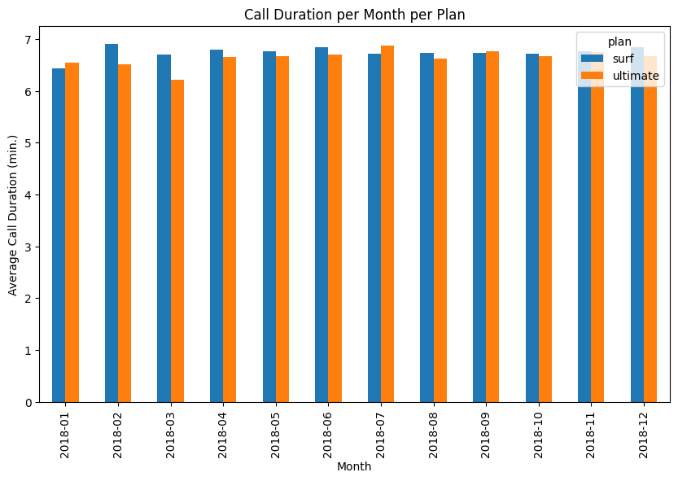

```python
calls_with_plans = calls.merge(users[['user_id','plan']], on='user_id')

grouped_call_data = calls_with_plans.groupby(['plan','year_month'])['duration'].mean()

plot_data = grouped_call_data.unstack(level=0)

plot_data.plot(kind = 'bar', xlabel = "Month", ylabel = "Average Call Duration (min.)", figsize = (10,6), title = "Call Duration per Month per Plan")

plt.show# Compare average duration of calls per each plan per each distinct month. Plot a bar plat to visualize it.
```

```
<function matplotlib.pyplot.show(close=None, block=None)>
```

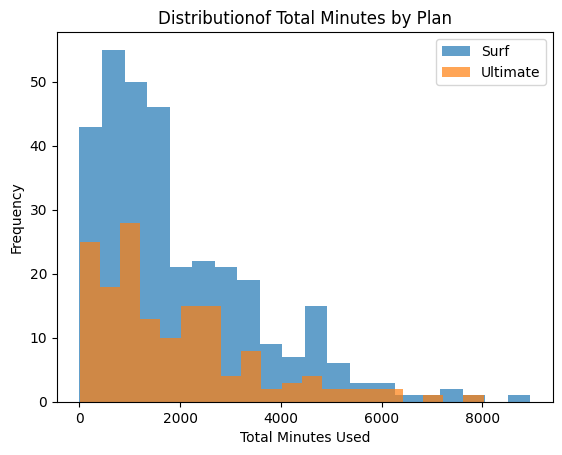

```python
minutes_per_plan =  calls.merge(users[['user_id','plan']], on='user_id')

grouped_minutes_data = minutes_per_plan.groupby(['user_id','plan','year_month'])['duration'].sum()

grouped_minutes = grouped_minutes_data.reset_index()

user_totals_from_grouped = grouped_minutes.groupby(['user_id', 'plan'])['duration'].sum().reset_index()
user_totals_from_grouped.columns = ['user_id', 'plan', 'total_minutes']

surf_minutes = user_totals_from_grouped[user_totals_from_grouped['plan'] == 'surf']['total_minutes']

ultimate_minutes = user_totals_from_grouped[user_totals_from_grouped['plan'] == 'ultimate']['total_minutes']


surf_minutes.plot(kind='hist',alpha=0.7,label="Surf",bins=20)
ultimate_minutes.plot(kind='hist',alpha=0.7,label="Ultimate",bins=20)

plt.title("Distributionof Total Minutes by Plan")
plt.xlabel("Total Minutes Used")
plt.ylabel("Frequency")
plt.legend()
plt.show # Compare the number of minutes users of each plan require each month. Plot a histogram.
```

[Calculate the mean and the variable of the call duration to reason on whether users on the different plans have different behaviours for their calls.]

```python
surf_user_mean = surf_minutes.mean()
surf_user_varience = surf_minutes.var()

ultimate_user_mean = ultimate_minutes.mean()
ultimate_user_varience = ultimate_minutes.var()

print(f"Mean of monthly call duration for Surf users: {surf_user_mean}")
print(f"Varience of monthly call duration for Surf users: {surf_user_varience}")
print(f"Mean of monthly call duration for Ultimate users: {ultimate_user_mean}")
print(f"Varience of monthly call duration of Ultimate users: {ultimate_user_varience}")# Calculate the mean and the variance of the monthly call duration
```

```
Mean of monthly call duration for Surf users: 1953.0406134969326
Varience of monthly call duration for Surf users: 2612436.136175007
Mean of monthly call duration for Ultimate users: 1886.8323870967743
Varience of monthly call duration of Ultimate users: 2560030.406631278
```

```
<function matplotlib.pyplot.show(close=None, block=None)>
```

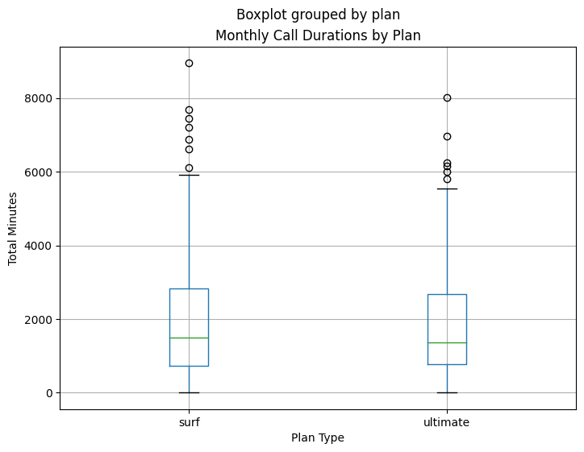

```python
plt.figure(figsize=(8,6))
user_totals_from_grouped.boxplot(column='total_minutes', by='plan', figsize=(8,6))
plt.title("Monthly Call Durations by Plan")
plt.ylabel("Total Minutes")
plt.xlabel("Plan Type")
plt.show# Plot a boxplot to visualize the distribution of the monthly call duration
```

Surf users look like they use more minutes than Ultimate, though not by much. Relatively, users between plans use roughly the same amount of minutes all year long.

### Messages

```
<function matplotlib.pyplot.show(close=None, block=None)>
```

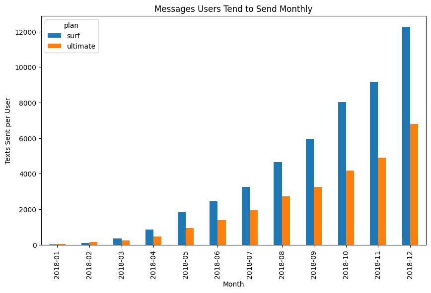

```python
texts_with_plans = messages.merge(users[['user_id','plan']], on='user_id')

grouped_text_data = texts_with_plans.groupby(['plan','year_month'])['text_id_per_user'].count()

plot_texts = grouped_text_data.unstack(level=0)

plot_texts.plot(kind = 'bar', xlabel = "Month", ylabel = "Texts Sent per User", figsize = (10,6), title = "Messages Users Tend to Send Monthly")

plt.show
```

Surf users started texting more on month 3 and continued to gradually increase texts sent in comparison to the Ultimate plan through the end of the year.

### Internet

```
<function matplotlib.pyplot.show(close=None, block=None)>
```

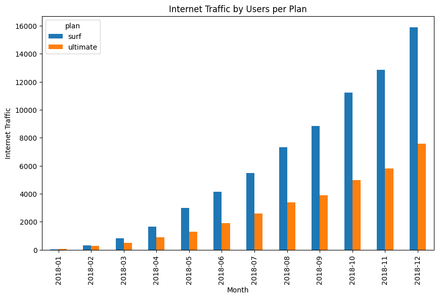

```python
data_with_plans = internet.merge(users[['user_id','plan']], on='user_id')

grouped_int_data = data_with_plans.groupby(['plan','year_month'])['internet_session'].count()

plot_int = grouped_int_data.unstack(level=0)

plot_int.plot(kind = 'bar', xlabel = "Month", ylabel = "Internet Traffic", figsize = (10,6), title = "Internet Traffic by Users per Plan")

plt.show

# Compare the amount of internet traffic consumed by users per plan
```

Surf users started internet more on month 3 and continued to gradually increase internet usage sent in comparison to the Ultimate plan through the end of the year.

**Reviewer's comment v1:**

Well done!

## Revenue

[Likewise you have studied the user behaviour, statistically describe the revenue between the plans.]

```python
surf_details = merged_with_plan_details[merged_with_plan_details['plan']=='surf']
surf_monthly_charges = merged_with_plan_details['monthly_cost'].sum()

surf_minutes_over = (surf_details['minutes_charged'] - surf_details['minutes_included'])
surf_minutes_over = surf_minutes_over.clip(lower=0)
surf_minutes_over_rev = surf_minutes_over * surf_details['usd_per_minute']
total_surf_minute_over_rev = surf_minutes_over_rev.sum()
print(f"Total Surf minute overage revenue: {total_surf_minute_over_rev}")

ultimate_details = merged_with_plan_details[merged_with_plan_details['plan']=='ultimate']
ultimate_monthly_charges = merged_with_plan_details['monthly_cost'].sum()
ultimate_minutes_over = (ultimate_details['minutes_charged'] - ultimate_details['minutes_included'])
ultimate_minutes_over = ultimate_minutes_over.clip(lower=0)
ultimate_minutes_over_rev = ultimate_minutes_over * ultimate_details['usd_per_minute']
total_ultimate_minute_over_rev = ultimate_minutes_over_rev.sum()
print(f"Total Ultimate minute overage revenue: {total_ultimate_minute_over_rev}")
```

```
Total Surf minute overage revenue: 2900.25
Total Ultimate minute overage revenue: 0.0
```

```python
surf_sms_over = (surf_details['sms_sent'] - surf_details['messages_included'])
surf_sms_over = surf_sms_over.clip(lower=0)
surf_sms_over_rev = surf_sms_over * surf_details['usd_per_message']
total_surf_sms_over_rev = surf_sms_over_rev.sum()
print(f"Total Surf message overage revenue: {total_surf_sms_over_rev}")

ultimate_sms_over = (ultimate_details['sms_sent'] - ultimate_details['messages_included'])
ultimate_sms_over = ultimate_sms_over.clip(lower=0)
ultimate_sms_over_rev = ultimate_sms_over * ultimate_details['usd_per_message']
total_ultimate_sms_over_rev = ultimate_sms_over_rev.sum()
print(f"Total Ultimate message overage revenue: {total_ultimate_sms_over_rev}")
```

```
Total Surf message overage revenue: 330.93
Total Ultimate message overage revenue: 0.0
```

```python
surf_data_over = (surf_details['data_monthly'] - surf_details['gb_per_month_included'])
surf_data_over = surf_data_over.clip(lower=0)
surf_data_over_rev = surf_data_over * surf_details['usd_per_gb']
total_surf_data_over_rev = surf_data_over_rev.sum()
print(f"Total Surf data overage revenue: {total_surf_data_over_rev}")

ultimate_data_over = (ultimate_details['data_monthly'] - ultimate_details['gb_per_month_included'])
ultimate_data_over = ultimate_data_over.clip(lower=0)
ultimate_data_over_rev = ultimate_data_over * ultimate_details['usd_per_gb']
total_ultimate_data_over_rev = ultimate_data_over_rev.sum()
print(f"Total Ultimate data overage revenue: {total_ultimate_data_over_rev}")
```

```
Total Surf data overage revenue: 56028.20673828125
Total Ultimate data overage revenue: 1523.5773437500002
```

```python
surf_minutes_over = (surf_details['minutes_charged'] - surf_details['minutes_included'])
surf_minutes_over = surf_minutes_over.clip(lower=0)
surf_sms_over = (surf_details['sms_sent'] - surf_details['messages_included'])
surf_sms_over = surf_sms_over.clip(lower=0)
surf_data_over = (surf_details['data_monthly'] - surf_details['gb_per_month_included'])
surf_data_over = surf_data_over.clip(lower=0)
total_surf_rev = surf_monthly_charges + surf_minutes_over.sum() + surf_sms_over.sum() + surf_data_over.sum()
print(f"Total Surf Revenue: {total_surf_rev}")
```

```
Total Surf Revenue: 195168.82067382813
```

```python
ultimate_minutes_over = (ultimate_details['minutes_charged'] - ultimate_details['minutes_included'])
ultimate_minutes_over = ultimate_minutes_over.clip(lower=0)
ultimate_sms_over = (ultimate_details['sms_sent'] - ultimate_details['messages_included'])
ultimate_sms_over = ultimate_sms_over.clip(lower=0)
ultimate_data_over = (ultimate_details['data_monthly'] - ultimate_details['gb_per_month_included'])
ultimate_data_over = ultimate_data_over.clip(lower=0)
total_ultimate_rev = ultimate_monthly_charges + ultimate_minutes_over.sum() + ultimate_sms_over.sum() + ultimate_data_over.sum()
print(f"Total Ultimate Revenue: {total_ultimate_rev}")
```

```
Total Ultimate Revenue: 82077.65390625
```

## Test statistical hypotheses

**Reviewer's comment v1:**

In this section, you should conduct hypothesis tests based on your data; you can refer to the following lesson: https://tripleten.com/trainer/data-scientist/lesson/e5a774f5-50ef-4dde-9715-1ba478558fea/?from=program

**Reviewer's comment v2:**

Well done both tests!

[Test the hypothesis that the average revenue from users of the Ultimate and Surf calling plans differs.]

[Formulate the null and the alternative hypotheses, choose the statistical test, decide on the alpha value.]

```python
merged_with_plan_details['surf_sms_over_rev'] = surf_sms_over_rev
merged_with_plan_details['ultimate_sms_over_rev'] = ultimate_sms_over_rev
merged_with_plan_details['surf_data_over_rev'] = surf_data_over_rev
merged_with_plan_details['ultimate_data_over_rev'] = ultimate_data_over_rev
merged_with_plan_details['surf_minutes_over_rev'] = surf_minutes_over_rev
merged_with_plan_details['ultimate_minutes_over_rev'] = ultimate_minutes_over_rev

revenue = merged_with_plan_details[['user_id', 'monthly_cost','plan','surf_sms_over_rev',
                                   'ultimate_sms_over_rev', 'surf_data_over_rev',
                                   'ultimate_data_over_rev', 'surf_minutes_over_rev',
                                   'ultimate_minutes_over_rev']].copy()

revenue['total_revenue'] = (revenue['monthly_cost'] +
                           revenue['surf_sms_over_rev'].fillna(0) +
                           revenue['ultimate_sms_over_rev'].fillna(0) +
                           revenue['surf_data_over_rev'].fillna(0) +
                           revenue['ultimate_data_over_rev'].fillna(0) +
                           revenue['surf_minutes_over_rev'].fillna(0) +
                           revenue['ultimate_minutes_over_rev'].fillna(0))
```

```python
surf_revenue = revenue[revenue['plan'] == 'surf']['total_revenue']
ultimate_revenue = revenue[revenue['plan'] == 'ultimate']['total_revenue']

alpha = 0.05
t_statistic, p_value = st.ttest_ind(surf_revenue, ultimate_revenue)

if p_value < alpha:
    print(f"\nDecision: Reject H0 (p-value {p_value:.4f} < alpha {alpha})")
    print("Conclusion: There IS a statistically significant difference in average revenue between plans")

    # Determine which plan has higher revenue
    if surf_revenue.mean() > ultimate_revenue.mean():
        print("Surf plan generates significantly higher average revenue")
    else:
        print("Ultimate plan generates significantly higher average revenue")
else:
    print(f"\nDecision: Fail to reject H0 (p-value {p_value:.4f} >= alpha {alpha})")
    print("Conclusion: There is NO statistically significant difference in average revenue between plans")

print()
print(f"Exact p-value: {p_value}")
print(f"P-value in scientific notation: {p_value: .2e}")
```

```
Decision: Reject H0 (p-value 0.0000 < alpha 0.05)
Conclusion: There IS a statistically significant difference in average revenue between plans
Ultimate plan generates significantly higher average revenue

Exact p-value: 1.341961045057078e-12
P-value in scientific notation:  1.34e-12
```

[Test the hypothesis that the average revenue from users in the NY-NJ area is different from that of the users from the other regions.]

[Formulate the null and the alternative hypotheses, choose the statistical test, decide on the alpha value.]

```python
revenue_with_regions = revenue.merge(merged_with_plan_details, on='user_id')
ny_nj_revenue = revenue_with_regions[revenue_with_regions['major_metro_region'] == 'New York-Newark-Jersey City, NY-NJ-PA MSA']['total_revenue']
other_revenue = revenue_with_regions[revenue_with_regions['major_metro_region'] != 'New York-Newark-Jersey City, NY-NJ-PA MSA']['total_revenue']

alpha = 0.05
t_statistic, p_value = st.ttest_ind(ny_nj_revenue, other_revenue)

if p_value < alpha:
    print(F"\nDecision: Reject H) (p-value {p_value: .4f} < alpha {alpha})")
    print("Conclustion: There IS a statistically significant difference in average revenue between regions")

     # Determine which region has higher revenue
    if ny_nj_revenue.mean() > other_revenue.mean():
        print("NY-NJ generates significantly higher average revenue")
    else:
        print("Other regions generate significantly higher average revenue")
else:
    print(f"\nDecision: Fail to reject H0 (p-value {p_value:.4f} >= alpha {alpha})")
    print("Conclusion: There is NO statistically significant difference in average revenue between regions")

print()
print(f"Exact p-value: {p_value}")
print(f"P-value in scientific notation: {p_value: .2e}")
```

```
Decision: Reject H) (p-value  0.0000 < alpha 0.05)
Conclustion: There IS a statistically significant difference in average revenue between regions
Other regions generate significantly higher average revenue

Exact p-value: 7.687390845008778e-19
P-value in scientific notation:  7.69e-19
```

## General conclusion

[List your important conclusions in this final section, make sure they cover all those important decisions (assumptions) that you've made and that led you to the way you processed and analyzed the data.]

Ultimately, Megaline has offered 2 great plans. Surf, which is pleasing to the eye for the monthly rate. The surf plan comes with a decent amount of data available for internet surfing, 500 minutes is just under about 9 hours of total talk time, and 50 texts, all this included just for $20 a month. Ultimate, on the other hand, is a high monthly cost - $70, gives much more talk and text time. The plan gives you only double the amount of data included, though 3,000 minutes (50 hours), and 1,000 text messages. An average consumer will assume that the higher dollar plan would come with more value - which to the eye, it does. Though, you can observe that a consumer willing to pay for the Surf plan, typically only needs a phone for call and text, and in comparison to Ultimate, you think theyre a heavy phone user - requiring more data. This is good to keep in mind when looking at generating revenue. Now, based on overage charges, they were very strategic here. On the Surf plan (low amount of calls and text, though generous on data for cost) has a 3 cent charge for every minute and message over. These easily add up - as you saw in my visual representations earlier. Whereas the Ultimate package does not have high overage cost, along with more value included in the plan. It will be a little harder to recieve more revenue from the Ultimate customers. You can also note on the fact that Ultimate users dont use a lot of minutes and messages (compared to the Surf users) and dont even reach their limit - so they are paying for services that they don't even use, and Megaline makes a profit on the unused minutes. Megaline's Surf plan brings in more revenue than the Ultimate plan overall, though makes more on average per user with their Ultimate plan.

**Reviewer's comment v1:**

Update your conclusions taking into account the results of the hypothesis tests.

**Reviewer's comment v2:**

Well done!